# correlation_biases_linear_CE_with_biases

```python
from lib_corr_matrices import *
import warnings
warnings.filterwarnings('ignore')
```

## visual analisys of cross correlation and correlaton matrices

For each model:

```python
paths2 = ['model_50_50/model_50_50_b2_1.csv',
          'model_50_50/model_50_50_b2_2.csv',
          'model_50_50/model_50_50_b2_3.csv',
          'model_50_50/model_50_50_b2_4.csv',
          'model_50_50/model_50_50_b2_5.csv',

          'model_50_50/model_50_50_b3_1.csv',
          'model_50_50/model_50_50_b3_2.csv',
          'model_50_50/model_50_50_b3_3.csv',
          'model_50_50/model_50_50_b3_4.csv',
          'model_50_50/model_50_50_b3_5.csv',
        ]
```

```python
paths3 = ['model_50_50_50/model_50_50_50_b2_1.csv',
          'model_50_50_50/model_50_50_50_b2_2.csv',
          'model_50_50_50/model_50_50_50_b2_3.csv',
          'model_50_50_50/model_50_50_50_b2_4.csv',
          'model_50_50_50/model_50_50_50_b2_5.csv',

          'model_50_50_50/model_50_50_50_b3_1.csv',
          'model_50_50_50/model_50_50_50_b3_2.csv',
          'model_50_50_50/model_50_50_50_b3_3.csv',
          'model_50_50_50/model_50_50_50_b3_4.csv',
          'model_50_50_50/model_50_50_50_b3_5.csv',

          'model_50_50_50/model_50_50_50_b4_1.csv',
          'model_50_50_50/model_50_50_50_b4_2.csv',
          'model_50_50_50/model_50_50_50_b4_3.csv',
          'model_50_50_50/model_50_50_50_b4_4.csv',
          'model_50_50_50/model_50_50_50_b4_5.csv',
         ]
```

```python
paths4 = ['model_50_50_50_50/model_50_50_50_50_b2_1.csv',
          'model_50_50_50_50/model_50_50_50_50_b2_2.csv',
          'model_50_50_50_50/model_50_50_50_50_b2_3.csv',
          'model_50_50_50_50/model_50_50_50_50_b2_4.csv',
          'model_50_50_50_50/model_50_50_50_50_b2_5.csv',

          'model_50_50_50_50/model_50_50_50_50_b3_1.csv',
          'model_50_50_50_50/model_50_50_50_50_b3_2.csv',
          'model_50_50_50_50/model_50_50_50_50_b3_3.csv',
          'model_50_50_50_50/model_50_50_50_50_b3_4.csv',
          'model_50_50_50_50/model_50_50_50_50_b3_5.csv',

          'model_50_50_50_50/model_50_50_50_50_b4_1.csv',
          'model_50_50_50_50/model_50_50_50_50_b4_2.csv',
          'model_50_50_50_50/model_50_50_50_50_b4_3.csv',
          'model_50_50_50_50/model_50_50_50_50_b4_4.csv',
          'model_50_50_50_50/model_50_50_50_50_b4_5.csv',

          'model_50_50_50_50/model_50_50_50_50_b5_1.csv',
          'model_50_50_50_50/model_50_50_50_50_b5_2.csv',
          'model_50_50_50_50/model_50_50_50_50_b5_3.csv',
          'model_50_50_50_50/model_50_50_50_50_b5_4.csv',
          'model_50_50_50_50/model_50_50_50_50_b5_5.csv'
]
```

get_correlation(paths2, k=1, max_epoch=400, folder='matrix_correlation_small/') get_correlation(paths3, k=1, max_epoch=400, folder='matrix_correlation_small/') get_correlation(paths4, k=1, max_epoch=400, folder='matrix_correlation_small/')

# Show all matrices

```python
cmap= newcmp

vmin_corr = -1
vmax_corr = 1

mineigenval = 1e-20
maxeigenval = 1e5
tol = 1e-18
n_of_samples=5
cutoff = 50

folder = 'matrix_correlation_small/'
```

# Eigenvalues spectrum all

pwd = 'model_50_50/model_50_50' folder = 'matrix_crosscorrelation/' d=3 show_eigenvalues_all(folder, pwd, d, n_of_samples, cmap, vmin_corr, vmax_corr, mineigenval, maxeigenval, cutoff = 1e-15)

pwd = 'model_50_50_50/model_50_50_50' folder = 'matrix_crosscorrelation/' d=4 show_eigenvalues_all(folder, pwd, d, n_of_samples, cmap, vmin_corr, vmax_corr, mineigenval, maxeigenval, cutoff = 1e-15)

pwd = 'model_50_50_50_50/model_50_50_50_50' folder = 'matrix_crosscorrelation/' d=5 show_eigenvalues_all(folder, pwd, d, n_of_samples, cmap, vmin_corr, vmax_corr, mineigenval, maxeigenval, cutoff = 1e-15)

# Show eigenvalues histogram

```
matrix_correlation_small/model_50_50/model_50_50_b2_ matrix shape = (50, 50)	 rank = 42
matrix_correlation_small/model_50_50/model_50_50_b2_ matrix shape = (50, 50)	 rank = 42
matrix_correlation_small/model_50_50/model_50_50_b2_ matrix shape = (50, 50)	 rank = 46
matrix_correlation_small/model_50_50/model_50_50_b2_ matrix shape = (50, 50)	 rank = 45
matrix_correlation_small/model_50_50/model_50_50_b2_ matrix shape = (50, 50)	 rank = 45
matrix_correlation_small/model_50_50/model_50_50_b3_ matrix shape = (10, 10)	 rank = 10
matrix_correlation_small/model_50_50/model_50_50_b3_ matrix shape = (10, 10)	 rank = 10
matrix_correlation_small/model_50_50/model_50_50_b3_ matrix shape = (10, 10)	 rank = 10
matrix_correlation_small/model_50_50/model_50_50_b3_ matrix shape = (10, 10)	 rank = 10
matrix_correlation_small/model_50_50/model_50_50_b3_ matrix shape = (10, 10)	 rank = 10
```

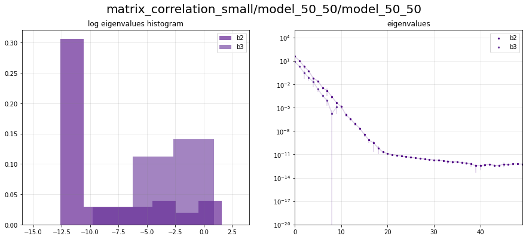

```python
pwd = 'model_50_50/model_50_50'
details = ['b2', 'b3']
show_eigenvalues_stacked(folder, pwd, details, n_of_samples, cmap, vmin_corr, vmax_corr, mineigenval, maxeigenval, cutoff)
```

```
matrix_correlation_small/model_50_50/model_50_50_b2_ matrix shape = (50, 50)	 rank = 42
matrix_correlation_small/model_50_50/model_50_50_b2_ matrix shape = (50, 50)	 rank = 42
matrix_correlation_small/model_50_50/model_50_50_b2_ matrix shape = (50, 50)	 rank = 46
matrix_correlation_small/model_50_50/model_50_50_b2_ matrix shape = (50, 50)	 rank = 45
matrix_correlation_small/model_50_50/model_50_50_b2_ matrix shape = (50, 50)	 rank = 45
matrix_correlation_small/model_50_50/model_50_50_b3_ matrix shape = (10, 10)	 rank = 10
matrix_correlation_small/model_50_50/model_50_50_b3_ matrix shape = (10, 10)	 rank = 10
matrix_correlation_small/model_50_50/model_50_50_b3_ matrix shape = (10, 10)	 rank = 10
matrix_correlation_small/model_50_50/model_50_50_b3_ matrix shape = (10, 10)	 rank = 10
matrix_correlation_small/model_50_50/model_50_50_b3_ matrix shape = (10, 10)	 rank = 10
```

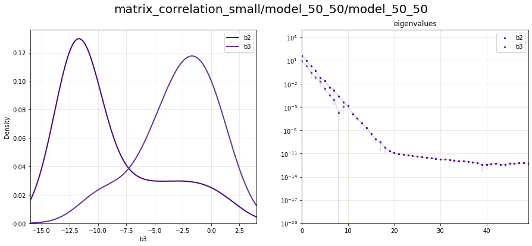

```python
pwd = 'model_50_50/model_50_50'
details = ['b2', 'b3']
show_eigenvalues_smoothed(folder, pwd, details, n_of_samples, cmap, vmin_corr, vmax_corr, mineigenval, maxeigenval, cutoff)
```

```
matrix_correlation_small/model_50_50_50/model_50_50_50_b2_ matrix shape = (50, 50)	 rank = 46
matrix_correlation_small/model_50_50_50/model_50_50_50_b2_ matrix shape = (50, 50)	 rank = 44
matrix_correlation_small/model_50_50_50/model_50_50_50_b2_ matrix shape = (50, 50)	 rank = 45
matrix_correlation_small/model_50_50_50/model_50_50_50_b2_ matrix shape = (50, 50)	 rank = 44
matrix_correlation_small/model_50_50_50/model_50_50_50_b2_ matrix shape = (50, 50)	 rank = 47
matrix_correlation_small/model_50_50_50/model_50_50_50_b3_ matrix shape = (50, 50)	 rank = 49
matrix_correlation_small/model_50_50_50/model_50_50_50_b3_ matrix shape = (50, 50)	 rank = 47
matrix_correlation_small/model_50_50_50/model_50_50_50_b3_ matrix shape = (50, 50)	 rank = 49
matrix_correlation_small/model_50_50_50/model_50_50_50_b3_ matrix shape = (50, 50)	 rank = 45
matrix_correlation_small/model_50_50_50/model_50_50_50_b3_ matrix shape = (50, 50)	 rank = 48
matrix_correlation_small/model_50_50_50/model_50_50_50_b4_ matrix shape = (10, 10)	 rank = 10
matrix_correlation_small/model_50_50_50/model_50_50_50_b4_ matrix shape = (10, 10)	 rank = 10
matrix_correlation_small/model_50_50_50/model_50_50_50_b4_ matrix shape = (10, 10)	 rank = 10
matrix_correlation_small/model_50_50_50/model_50_50_50_b4_ matrix shape = (10, 10)	 rank = 10
matrix_correlation_small/model_50_50_50/model_50_50_50_b4_ matrix shape = (10, 10)	 rank = 10
```

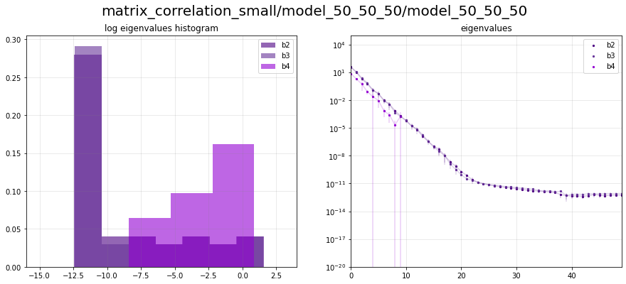

```python
pwd = 'model_50_50_50/model_50_50_50'
details = ['b2', 'b3', 'b4']
show_eigenvalues_stacked(folder, pwd, details, n_of_samples, cmap, vmin_corr, vmax_corr, mineigenval, maxeigenval, cutoff)
```

```
matrix_correlation_small/model_50_50_50/model_50_50_50_b2_ matrix shape = (50, 50)	 rank = 46
matrix_correlation_small/model_50_50_50/model_50_50_50_b2_ matrix shape = (50, 50)	 rank = 44
matrix_correlation_small/model_50_50_50/model_50_50_50_b2_ matrix shape = (50, 50)	 rank = 45
matrix_correlation_small/model_50_50_50/model_50_50_50_b2_ matrix shape = (50, 50)	 rank = 44
matrix_correlation_small/model_50_50_50/model_50_50_50_b2_ matrix shape = (50, 50)	 rank = 47
matrix_correlation_small/model_50_50_50/model_50_50_50_b3_ matrix shape = (50, 50)	 rank = 49
matrix_correlation_small/model_50_50_50/model_50_50_50_b3_ matrix shape = (50, 50)	 rank = 47
matrix_correlation_small/model_50_50_50/model_50_50_50_b3_ matrix shape = (50, 50)	 rank = 49
matrix_correlation_small/model_50_50_50/model_50_50_50_b3_ matrix shape = (50, 50)	 rank = 45
matrix_correlation_small/model_50_50_50/model_50_50_50_b3_ matrix shape = (50, 50)	 rank = 48
matrix_correlation_small/model_50_50_50/model_50_50_50_b4_ matrix shape = (10, 10)	 rank = 10
matrix_correlation_small/model_50_50_50/model_50_50_50_b4_ matrix shape = (10, 10)	 rank = 10
matrix_correlation_small/model_50_50_50/model_50_50_50_b4_ matrix shape = (10, 10)	 rank = 10
matrix_correlation_small/model_50_50_50/model_50_50_50_b4_ matrix shape = (10, 10)	 rank = 10
matrix_correlation_small/model_50_50_50/model_50_50_50_b4_ matrix shape = (10, 10)	 rank = 10
```

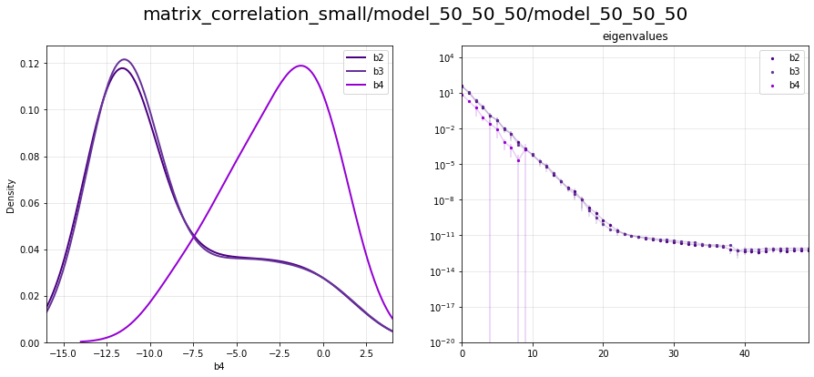

```python
pwd = 'model_50_50_50/model_50_50_50'
details = ['b2', 'b3', 'b4']
show_eigenvalues_smoothed(folder, pwd, details, n_of_samples, cmap, vmin_corr, vmax_corr, mineigenval, maxeigenval, cutoff)
```

```
matrix_correlation_small/model_50_50_50_50/model_50_50_50_50_b2_ matrix shape = (50, 50)	 rank = 46
matrix_correlation_small/model_50_50_50_50/model_50_50_50_50_b2_ matrix shape = (50, 50)	 rank = 48
matrix_correlation_small/model_50_50_50_50/model_50_50_50_50_b2_ matrix shape = (50, 50)	 rank = 45
matrix_correlation_small/model_50_50_50_50/model_50_50_50_50_b2_ matrix shape = (50, 50)	 rank = 46
matrix_correlation_small/model_50_50_50_50/model_50_50_50_50_b2_ matrix shape = (50, 50)	 rank = 44
matrix_correlation_small/model_50_50_50_50/model_50_50_50_50_b3_ matrix shape = (50, 50)	 rank = 47
matrix_correlation_small/model_50_50_50_50/model_50_50_50_50_b3_ matrix shape = (50, 50)	 rank = 47
matrix_correlation_small/model_50_50_50_50/model_50_50_50_50_b3_ matrix shape = (50, 50)	 rank = 47
matrix_correlation_small/model_50_50_50_50/model_50_50_50_50_b3_ matrix shape = (50, 50)	 rank = 48
matrix_correlation_small/model_50_50_50_50/model_50_50_50_50_b3_ matrix shape = (50, 50)	 rank = 44
matrix_correlation_small/model_50_50_50_50/model_50_50_50_50_b4_ matrix shape = (50, 50)	 rank = 48
matrix_correlation_small/model_50_50_50_50/model_50_50_50_50_b4_ matrix shape = (50, 50)	 rank = 50
matrix_correlation_small/model_50_50_50_50/model_50_50_50_50_b4_ matrix shape = (50, 50)	 rank = 49
matrix_correlation_small/model_50_50_50_50/model_50_50_50_50_b4_ matrix shape = (50, 50)	 rank = 49
matrix_correlation_small/model_50_50_50_50/model_50_50_50_50_b4_ matrix shape = (50, 50)	 rank = 48
matrix_correlation_small/model_50_50_50_50/model_50_50_50_50_b5_ matrix shape = (10, 10)	 rank = 10
matrix_correlation_small/model_50_50_50_50/model_50_50_50_50_b5_ matrix shape = (10, 10)	 rank = 10
matrix_correlation_small/model_50_50_50_50/model_50_50_50_50_b5_ matrix shape = (10, 10)	 rank = 10
matrix_correlation_small/model_50_50_50_50/model_50_50_50_50_b5_ matrix shape = (10, 10)	 rank = 10
matrix_correlation_small/model_50_50_50_50/model_50_50_50_50_b5_ matrix shape = (10, 10)	 rank = 10
```

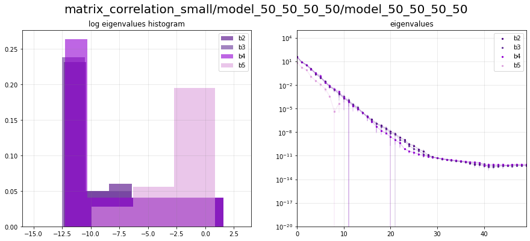

```python
pwd = 'model_50_50_50_50/model_50_50_50_50'
details = ['b2', 'b3', 'b4', 'b5']
show_eigenvalues_stacked(folder, pwd, details, n_of_samples, cmap, vmin_corr, vmax_corr, mineigenval, maxeigenval, cutoff)
```

```
matrix_correlation_small/model_50_50_50_50/model_50_50_50_50_b2_ matrix shape = (50, 50)	 rank = 46
matrix_correlation_small/model_50_50_50_50/model_50_50_50_50_b2_ matrix shape = (50, 50)	 rank = 48
matrix_correlation_small/model_50_50_50_50/model_50_50_50_50_b2_ matrix shape = (50, 50)	 rank = 45
matrix_correlation_small/model_50_50_50_50/model_50_50_50_50_b2_ matrix shape = (50, 50)	 rank = 46
matrix_correlation_small/model_50_50_50_50/model_50_50_50_50_b2_ matrix shape = (50, 50)	 rank = 44
matrix_correlation_small/model_50_50_50_50/model_50_50_50_50_b3_ matrix shape = (50, 50)	 rank = 47
matrix_correlation_small/model_50_50_50_50/model_50_50_50_50_b3_ matrix shape = (50, 50)	 rank = 47
matrix_correlation_small/model_50_50_50_50/model_50_50_50_50_b3_ matrix shape = (50, 50)	 rank = 47
matrix_correlation_small/model_50_50_50_50/model_50_50_50_50_b3_ matrix shape = (50, 50)	 rank = 48
matrix_correlation_small/model_50_50_50_50/model_50_50_50_50_b3_ matrix shape = (50, 50)	 rank = 44
matrix_correlation_small/model_50_50_50_50/model_50_50_50_50_b4_ matrix shape = (50, 50)	 rank = 48
matrix_correlation_small/model_50_50_50_50/model_50_50_50_50_b4_ matrix shape = (50, 50)	 rank = 50
matrix_correlation_small/model_50_50_50_50/model_50_50_50_50_b4_ matrix shape = (50, 50)	 rank = 49
matrix_correlation_small/model_50_50_50_50/model_50_50_50_50_b4_ matrix shape = (50, 50)	 rank = 49
matrix_correlation_small/model_50_50_50_50/model_50_50_50_50_b4_ matrix shape = (50, 50)	 rank = 48
matrix_correlation_small/model_50_50_50_50/model_50_50_50_50_b5_ matrix shape = (10, 10)	 rank = 10
matrix_correlation_small/model_50_50_50_50/model_50_50_50_50_b5_ matrix shape = (10, 10)	 rank = 10
matrix_correlation_small/model_50_50_50_50/model_50_50_50_50_b5_ matrix shape = (10, 10)	 rank = 10
matrix_correlation_small/model_50_50_50_50/model_50_50_50_50_b5_ matrix shape = (10, 10)	 rank = 10
matrix_correlation_small/model_50_50_50_50/model_50_50_50_50_b5_ matrix shape = (10, 10)	 rank = 10
```

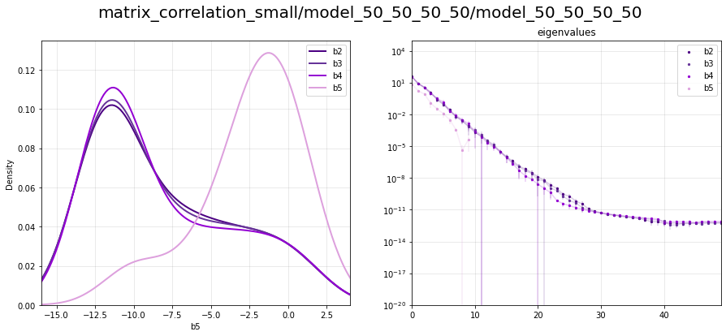

```python
details = ['b2', 'b3', 'b4', 'b5']
show_eigenvalues_smoothed(folder, pwd, details, n_of_samples, cmap, vmin_corr, vmax_corr, mineigenval, maxeigenval, cutoff)
```

# Plots one by one

```
matrix shape = (50, 50)		 rank = 50
matrix shape = (50, 50)		 rank = 50
matrix shape = (50, 50)		 rank = 50
matrix shape = (50, 50)		 rank = 50
matrix shape = (50, 50)		 rank = 50
```

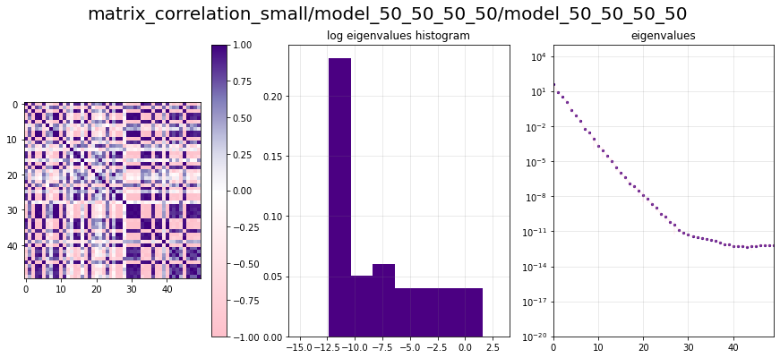

```python
pwd = 'model_50_50_50_50/model_50_50_50_50'
d='b2'
show_eigenvalues(folder, pwd, d, n_of_samples, cmap, vmin_corr, vmax_corr, mineigenval, maxeigenval, tol)
```

```
matrix shape = (50, 50)		 rank = 50
matrix shape = (50, 50)		 rank = 50
matrix shape = (50, 50)		 rank = 50
matrix shape = (50, 50)		 rank = 50
matrix shape = (50, 50)		 rank = 50
```

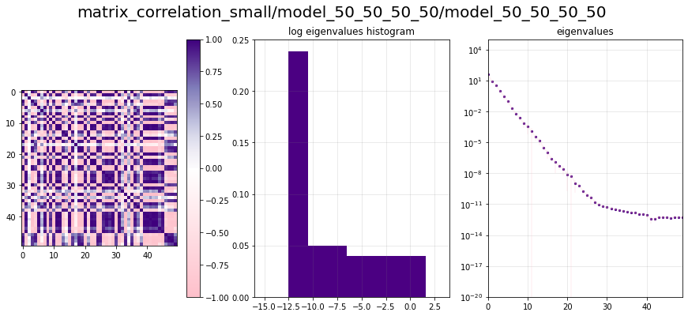

```python
pwd = 'model_50_50_50_50/model_50_50_50_50'
d='b3'
show_eigenvalues(folder, pwd, d, n_of_samples, cmap, vmin_corr, vmax_corr, mineigenval, maxeigenval, tol)
```

```
matrix shape = (50, 50)		 rank = 50
matrix shape = (50, 50)		 rank = 50
matrix shape = (50, 50)		 rank = 50
matrix shape = (50, 50)		 rank = 50
matrix shape = (50, 50)		 rank = 50
```

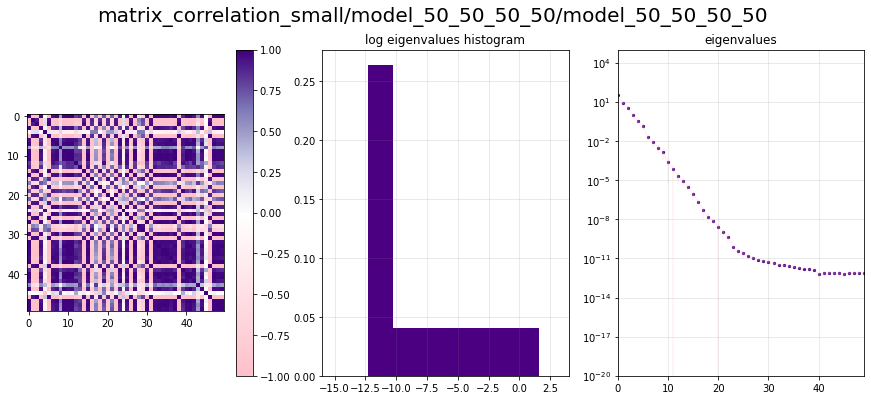

```python
pwd = 'model_50_50_50_50/model_50_50_50_50'
d='b4'
show_eigenvalues(folder, pwd, d, n_of_samples, cmap, vmin_corr, vmax_corr, mineigenval, maxeigenval, tol)
```

```
matrix shape = (10, 10)		 rank = 10
matrix shape = (10, 10)		 rank = 10
matrix shape = (10, 10)		 rank = 10
matrix shape = (10, 10)		 rank = 10
matrix shape = (10, 10)		 rank = 10
```

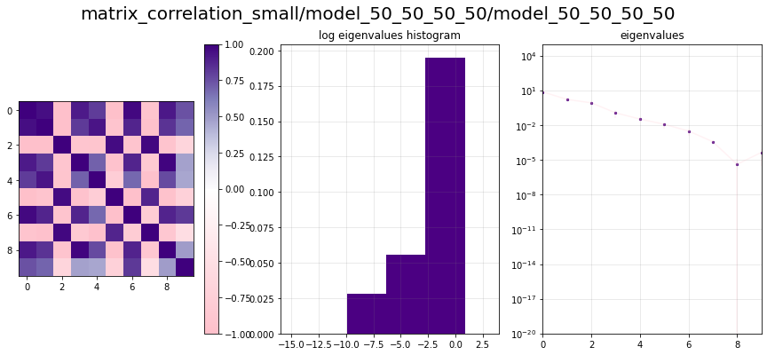

```python
pwd = 'model_50_50_50_50/model_50_50_50_50'
d='b5'
show_eigenvalues(folder, pwd, d, n_of_samples, cmap, vmin_corr, vmax_corr, mineigenval, maxeigenval, tol)
```